# HW2

### Textbook 10.3.3 problem 3

How many diamonds are 0.99 carat? How many are 1 carat?

What do you think is the cause of the difference?

```r
diamonds %>%
  filter(carat == 0.99 | carat == 1) %>%
  summarise(n = n(), .by = carat)
```

```
## # A tibble: 2 × 2
##   carat     n
##   <dbl> <int>
## 1  1     1558
## 2  0.99    23
```

```r
#0.99 캐럿 다이아몬드는 23개이다.
#1 캐럿 다이아몬드는 1558개이다.
#굉장히 극단적인 차이를 볼 수 있다.
#정수 캐럿으로 만들기가 쉽거나, 사람들의 수요가 많기 때문일 것 같다.
```

### Textbook 10.5.1.1 problem 2

Use what you’ve learned to improve the visualization of the departure times of cancelled vs. non-cancelled flights.

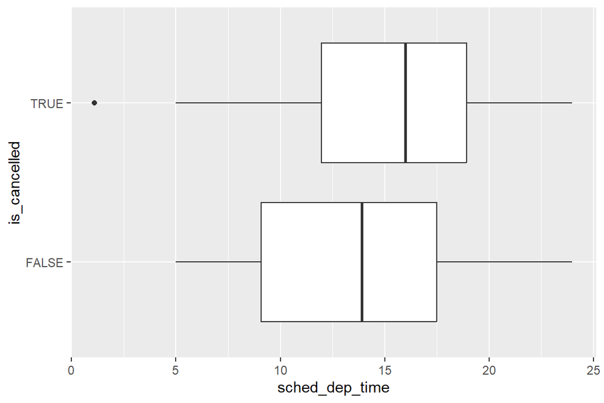

```r
new_flights <- flights %>%
  mutate(
    is_cancelled = is.na(dep_time),
    sched_dep_time = (sched_dep_time %/% 100) + (sched_dep_time %% 100) / 60
  ) %>%
  select(sched_dep_time, is_cancelled)

new_flights %>%
  ggplot(aes(x = sched_dep_time, y = is_cancelled)) +
  geom_boxplot()
```

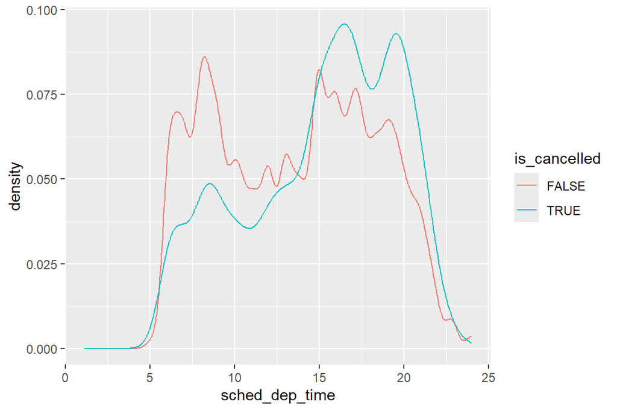

```r
#취소된 항공편들의 예정 출발시간이 더 늦다.

new_flights %>%
  ggplot(aes(x = sched_dep_time, color = is_cancelled)) +
  geom_freqpoly(stat = "density")
```

```r
#밀도 함수를 이용해서도 확인할 수 있다.
```

### Textbook 13.5.4 problem 7

Look at each destination.

Can you find flights that are suspiciously fast (i.e. flights that represent a potential data entry error)?

Compute the air time of a flight relative to the shortest flight to that destination.

Which flights were most delayed in the air?

```r
dest_air_time <- flights %>%
  group_by(dest) %>%
  mutate(
    min_air_time = min(air_time, na.rm = TRUE),
    mean_air_time = mean(air_time, na.rm = TRUE),
    relative = min_air_time / air_time,
    sched_dep_time = (sched_dep_time %/% 100) * 60 + (sched_dep_time %% 100),
    sched_arr_time = (sched_arr_time %/% 100) * 60 + (sched_arr_time %% 100)
  ) %>%
  select(
    dest, air_time, min_air_time, mean_air_time,
    relative, sched_dep_time, sched_arr_time
  ) %>%
  ungroup()

dest_air_time %>%
  mutate(diff = min_air_time - mean_air_time) %>%
  arrange(diff, air_time) %>%
  select(dest, air_time, min_air_time, mean_air_time, diff, relative)
```

```
## # A tibble: 336,776 × 6
##    dest  air_time min_air_time mean_air_time  diff relative
##    <chr>    <dbl>        <dbl>         <dbl> <dbl>    <dbl>
##  1 MSP         93           93          151. -57.6    1
##  2 MSP        122           93          151. -57.6    0.762
##  3 MSP        123           93          151. -57.6    0.756
##  4 MSP        123           93          151. -57.6    0.756
##  5 MSP        123           93          151. -57.6    0.756
##  6 MSP        124           93          151. -57.6    0.75
##  7 MSP        125           93          151. -57.6    0.744
##  8 MSP        125           93          151. -57.6    0.744
##  9 MSP        125           93          151. -57.6    0.744
## 10 MSP        126           93          151. -57.6    0.738
## # ℹ 336,766 more rows
```

```r
#MSP로 가는 항공편은 평균 151분인데 93분인 비행이 있다.
#93분 비행과 그 다음으로 짧은 비행이 122분으로 30분 정도나 차이가 나는 걸 보아, 잘못 입력했을 것 같다.

#예정 공중 시간을 계산해서 공중 지연을 계산하자.
dest_air_time %>%
  mutate(
    sched_air_time = ifelse(
      sched_arr_time > sched_dep_time,
      sched_arr_time - sched_dep_time,
      sched_arr_time - sched_dep_time + 1440
    ),
    diff = air_time - sched_air_time
  ) %>%
  select(dest, air_time, sched_dep_time,
    sched_arr_time, sched_air_time, diff
  ) %>%
  arrange(desc(diff))
```

```
## # A tibble: 336,776 × 6
##    dest  air_time sched_dep_time sched_arr_time sched_air_time  diff
##    <chr>    <dbl>          <dbl>          <dbl>          <dbl> <dbl>
##  1 HNL        695            815           1116            301   394
##  2 HNL        666            810           1095            285   381
##  3 HNL        650            600            875            275   375
##  4 HNL        671            815           1116            301   370
##  5 HNL        640            600            875            275   365
##  6 HNL        671            600            910            310   361
##  7 HNL        661            815           1116            301   360
##  8 HNL        640            600            880            280   360
##  9 HNL        634            600            875            275   359
## 10 HNL        629            600            870            270   359
## # ℹ 336,766 more rows
```

```r
#HNL로 가는 air_time 695분 짜리 비행이 공중지연이 가장 심하다.
```

### Textbook 13.5.4 problem 8

Find all destinations that are flown by at least two carriers.

Use those destinations to come up with a relative ranking of the carriers based on their performance for the same destination.

```r
two_carrier_dest <- flights %>%
  count(dest, carrier) %>%
  count(dest) %>%
  filter(n > 1) %>%
  .$dest

#평균 도착 지연이 낮은 순으로 랭킹을 매기자.
carrier_rank <- flights %>%
  filter(dest %in% two_carrier_dest) %>%
  group_by(dest, carrier) %>%
  summarise(mean_delay = mean(arr_delay, na.rm = TRUE)) %>%
  arrange(dest, mean_delay)
carrier_rank
```

```
## # A tibble: 285 × 3
## # Groups:   dest [76]
##    dest  carrier mean_delay
##    <chr> <chr>        <dbl>
##  1 ATL   9E           0.857
##  2 ATL   WN           6.90
##  3 ATL   DL           7.42
##  4 ATL   UA          10.5
##  5 ATL   MQ          14.0
##  6 ATL   EV          19.6
##  7 ATL   FL          20.7
##  8 AUS   WN         -11.2
##  9 AUS   9E          -3.5
## 10 AUS   DL           1.41
## # ℹ 275 more rows
```

```r
#목적지별로 평균지연이 낮은 순으로 정렬하였다.

carrier_rank %>%
  group_by(dest) %>%
  summarise(
    good_carrier = first(carrier),
    mean_delay = first(mean_delay)
  )
```

```
## # A tibble: 76 × 3
##    dest  good_carrier mean_delay
##    <chr> <chr>             <dbl>
##  1 ATL   9E                0.857
##  2 AUS   WN              -11.2
##  3 AVL   9E              -12.1
##  4 BDL   EV                6.78
##  5 BGR   EV                8.03
##  6 BNA   DL              -27
##  7 BOS   EV               -4.01
##  8 BQN   B6                6.94
##  9 BTV   9E               -2.5
## 10 BUF   DL              -11.7
## # ℹ 66 more rows
```

```r
#각 목적지 별로 우수 carrier만 놔둔 표이다.
```